# The Role of Urea Treatment on *Arabidopsis thaliana* Stress Response Over Time

# About The Dataset

This data was retrieved from a study that focused on the role of exogenous glutamate (Glu) treatments in inducing immune responses in *Arabidopsis thalia*. The study consisted of treatments over time to Arabidopsis that was under stress by bacterial pathogens. The authors then examined the stress response genes impacted. They used urea as a treatment as well to ensure that nitrogen levels were accounted for in order to isolate genes that were only impacted by glutamate. In total, the authors had 3 replicates per treatment group, the treatment groups were administered at 6 hours, 24 hours and 48 hours, with the mock group administered at 0 hours (control of water).

This project was interested in the role of urea in the stress response of *Arabidopsis thalia* and downloaded data of only the 3 mock replicates, the 6 hour urea treatment replicates , and the 48 hour urea treatment replicates. The goal was to evaluate the different time applications of urea on Arabidopsis response to pathogen stress. The hypothesis being that the longer exposure to urea treatment induces pathogen stress tolerance.

GEO Accession:

GSE123622

Citation:

Goto, Y., Maki, N., Ichihashi, Y., Kitazawa, D., Igarashi, D., Kadota, Y., & Shirasu, K. (2020). Exogenous Treatment with Glutamate Induces Immune Responses in Arabidopsis. Molecular plant-microbe interactions : MPMI, 33(3), 474–487. https://doi.org/10.1094/MPMI-09-19-0262-R

# Setting Up the Workflow

## Setting the Working Directory and Loading Libraries

## Loading the Metadata Table

Meta data was originally sourced from the SRA Run Selector, but after having issues with implementation into R, Dr. Rodriguez provided the one below. This was then implemented using the read.csv function and named coldata.

```r
coldata <- read.csv("meta_RV.csv",
                        header = T,
                        row.names = 1)

head(coldata)
```

```
##            treatment time replicate    group
## SRR8311214      mock   0h         1  mock_0h
## SRR8311215      mock   0h         2  mock_0h
## SRR8311216      mock   0h         3  mock_0h
## SRR8311218      urea   6h         1  urea_6h
## SRR8311219      urea   6h         2  urea_6h
## SRR8311226      urea  48h         1 urea_48h
```

## Converting to a Data Frame

Titled the object “sampleTable”

```r
sampleTable <- data.frame(coldata)
head(sampleTable)
```

```
##            treatment time replicate    group
## SRR8311214      mock   0h         1  mock_0h
## SRR8311215      mock   0h         2  mock_0h
## SRR8311216      mock   0h         3  mock_0h
## SRR8311218      urea   6h         1  urea_6h
## SRR8311219      urea   6h         2  urea_6h
## SRR8311226      urea  48h         1 urea_48h
```

```r
str(sampleTable)
```

```
## 'data.frame':    8 obs. of  4 variables:
##  $ treatment: chr  "mock" "mock" "mock" "urea" ...
##  $ time     : chr  "0h" "0h" "0h" "6h" ...
##  $ replicate: int  1 2 3 1 2 1 2 3
##  $ group    : chr  "mock_0h" "mock_0h" "mock_0h" "urea_6h" ...
```

## Loading the Counts Matrix

The counts matrix was created in a couple of steps, starting with the implementation of our raw unstranded counts files from the VACC, located at a file path that we named as “main_dir”. The files were then assigned to the object “count_data” by list.files using the object “main_dir”. Next readDGE was used to convert the .txt files into a matrix like table. We then corrected the column names to fit into our dataset better as not to have any interruptions down the line due to the necessity of formatting for DESeq. This was then saved as a .csv file. It was subsequently read in and set as a matrix.

The file path to the object “main_dir” was used since there were issues when assigning the file path to the “path =” part of the list.files function. When recreating the document, using the “main_dir” object may not be necessary as the files are located in folder titled “count_data” in the submission folder, and the counts matrix itself is attached there as well.

```r
#lines 82-97 may not be needed as the counts matrix is attached in the submission, but it is included for reference.
main_dir <- "/gpfs1/home/r/v/rvanvran/final_proj/fastq/trimmed_output2/counts/Unstranded_Counts/count_data"

count_data <- list.files(path = main_dir,
                         pattern = "\\.txt$",
                         recursive = TRUE,
                         full.names = TRUE)

#print(count_data)

counts <- readDGE(count_data, columns = c(1,2))$counts
```

```
## Meta tags detected: __no_feature, __ambiguous, __too_low_aQual, __not_aligned, __alignment_not_unique
```

```r
colnames(counts) <- c("SRR8311214", "SRR8311215", "SRR8311216", "SRR8311218", "SRR8311219", "SRR8311226", "SRR8311227", "SRR8311228"
         )
#counts

#write.csv(counts, file = "counts_matrix.csv", row.names = TRUE)

countdata <- read.csv("counts_matrix.csv",
                      header=TRUE,
                      row.names=1)

countdata <- as.matrix(countdata)
```

```r
colnames(countdata)
```

```
## [1] "SRR8311214" "SRR8311215" "SRR8311216" "SRR8311218" "SRR8311219"
## [6] "SRR8311226" "SRR8311227" "SRR8311228"
```

## Confirming the proper format for DESeq

```r
all(colnames(countdata) == rownames(coldata))
```

```
## [1] TRUE
```

# DESeq

We used DESeqDataSetFromMatrix because we set the count data as a matrix and the names of the data used are self explanatory, where coldata is our metadata table from above, and countdata is the counts matrix.

```r
dds <- DESeqDataSetFromMatrix(countData = countdata,
                              colData = coldata,
                              design = ~ group)
dds
```

```
## class: DESeqDataSet
## dim: 32837 8
## metadata(1): version
## assays(1): counts
## rownames(32837): AT1G01020 AT1G01030 ... __not_aligned
##   __alignment_not_unique
## rowData names(0):
## colnames(8): SRR8311214 SRR8311215 ... SRR8311227 SRR8311228
## colData names(4): treatment time replicate group
```

## Pre-Filtering

Although not always necessary, we chose to pre-filter mainly to ensure that future plots are cleaner by ensuring super low counts (or no count data cells) are not plotted. Also this helps to reduce file sizes and speed up the computation.

```r
keep <- rowSums(counts(dds)) >= 10
dds <- dds[keep,]
```

## Running DESeq

```r
dds <- DESeq(dds)
```

## Releveling to Set the Reference Group as the Control

In this dataset, it is the mock_0h group.

```r
dds$group <- relevel(dds$group, ref = "mock_0h")
```

# Generating a PCA Plot

## Preparing Data to Run a PCA Plot

In this chunk of code, the first step applies a variance-stabilizing transformation (vst) on the DESeqDataSet. Then plotPCA preforms the calculations of Principal Component Analysis.

```r
vstcounts <- vst(dds, blind = FALSE)

pcaData <- plotPCA(vstcounts, intgroup=c("group"),
                   returnData=TRUE)
```

```
## using ntop=500 top features by variance
```

```r
percentVar <- round(100 * attr(pcaData, "percentVar"))
```

## Creating a PCA Plot with a Figure Caption

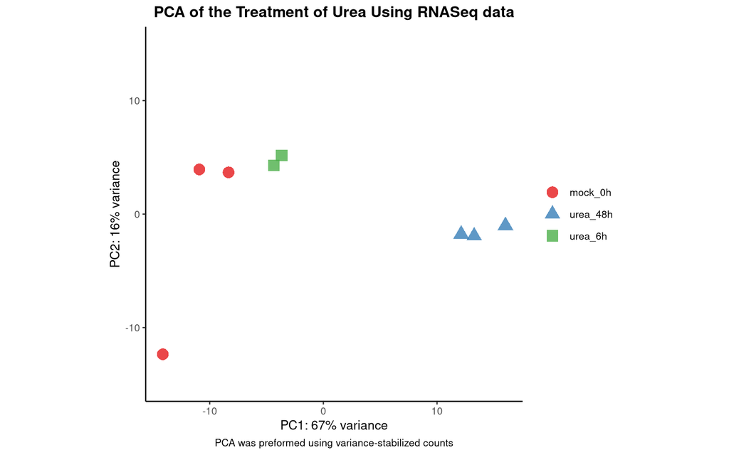

```r
Final_PCA <- ggplot(pcaData, aes(PC1, PC2, color = group, shape = group)) +
  geom_point(size = 4, alpha = 0.8) +
  ylim(-15, 15) +
  xlab(paste0("PC1: ", percentVar[1], "% variance")) +
  ylab(paste0("PC2: ", percentVar[2], "% variance")) +
  coord_fixed() +
  ggtitle("PCA of the Treatment of Urea Using RNASeq data") +
  labs(caption = "PCA was preformed using variance-stabilized counts") +
  scale_color_brewer(palette = "Set1") +
  theme_classic(base_size = 10) +
  theme(
    legend.position = "right",
    legend.title = element_blank(),
    plot.title = element_text(hjust = 0.5, face = "bold"),
    plot.caption = element_text(hjust = 0.5, size = 8)
  )

Final_PCA
```

```r
#ggsave("FinalPCA.pdf", plot = Final_PCA, width = 6, height = 5)
```

# Interpreting the DESeq Data

## Running the Results Function on the DESeq Output

This was done in order to further plot and interpret data, as well as a checkpoint on the data. The results() function is used for each treatment group in order to start the pairwise comparisons.

```r
res_urea6h_mock0h <- results(dds, contrast=c('group', 'urea_6h', 'mock_0h'))
#head(res_urea6h_mock0h)

res_urea48h_mock0h <- results(dds, contrast=c('group', 'urea_48h', 'mock_0h'))
#head(res_urea48h_mock0h)

res_urea48h_urea6h <- results(dds, contrast=c('group', 'urea_48h', 'urea_6h'))
#head(res_urea48h_urea6h)

#summary(res_urea6h_mock0h)
#summary(res_urea48h_mock0h)
#summary(res_urea48h_urea6h)

#str(res_urea6h_mock0h)
#str(res_urea48h_mock0h)
#str(res_urea48h_urea6h)
```

## Conducting plotMA

The plotMA outputs here can be used to compare and ensure that the lfcShrink function (used later) worked. It is also a checkpoint to make sure the code is working as intended by exploring the relationship between log2fold changes, significant DE genes and the genes mean count. The table() function is used to gauge sizes of significant DE genes.

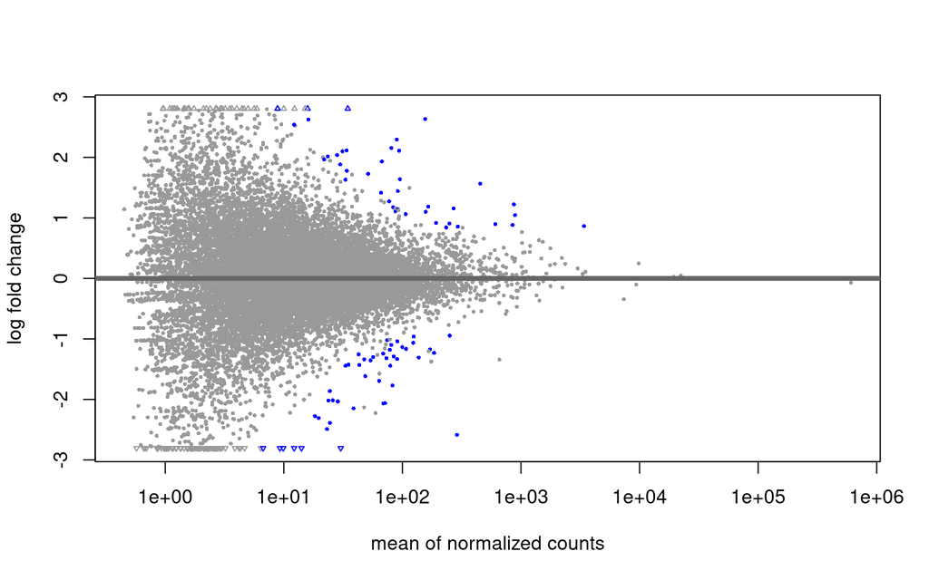

```r
plotMA(res_urea6h_mock0h)
```

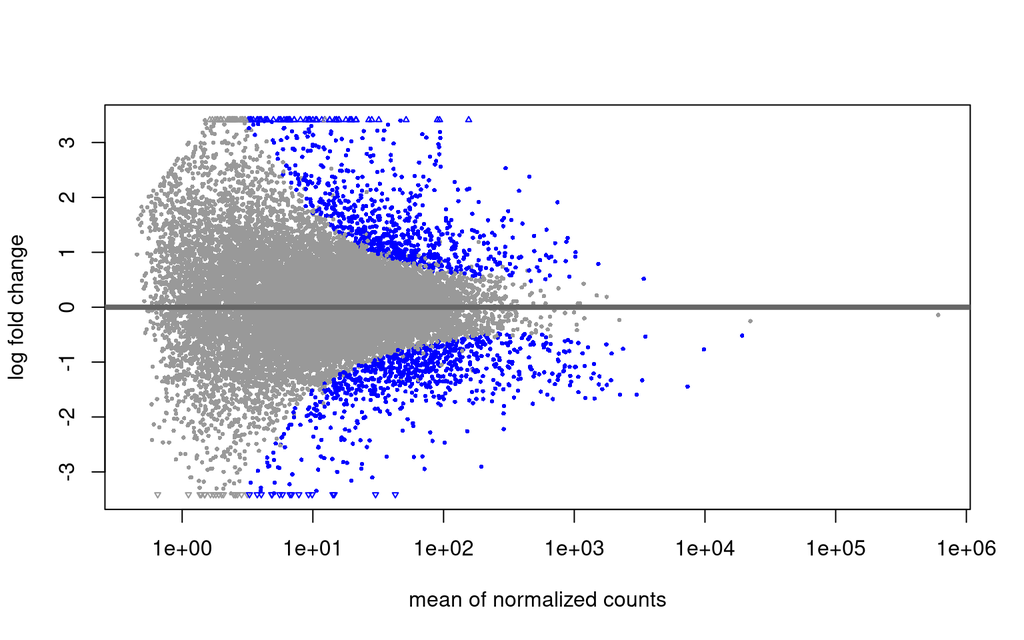

```r
plotMA(res_urea48h_mock0h)
```

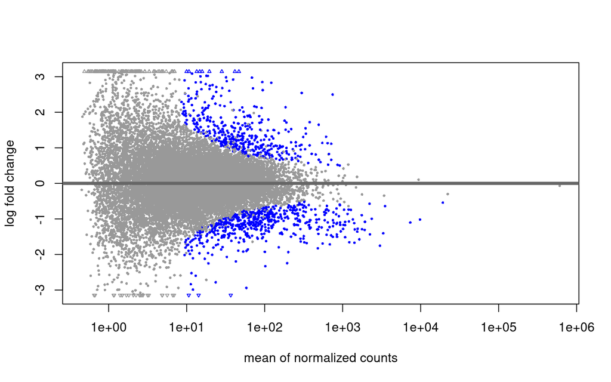

```r
plotMA(res_urea48h_urea6h)
```

```r
resultsNames(dds)
```

```
## [1] "Intercept"                 "group_urea_48h_vs_mock_0h"
## [3] "group_urea_6h_vs_mock_0h"
```

```r
table(res_urea6h_mock0h$padj<0.05)
```

```
##
## FALSE  TRUE
## 14344    56
```

```r
table(res_urea48h_mock0h$padj<0.05)
```

```
##
## FALSE  TRUE
## 14282  1209
```

```r
table(res_urea48h_urea6h$padj<0.05)
```

```
##
## FALSE  TRUE
## 10727   762
```

# GeneID Conversion - lfcShrink and Volcano Plots for Each Comparison.

This step was kindly preformed by Dr. Rodriguez due to errors in loading genekitr on my (rvanvran) VACC. In order for Dr. Rodriguez to preform this though, the data for each comparison needed to undergo lfcShrink which shrinks the log fold changes to a manageable and readable output (can be seen visually in the plotMA functions before and after this step). These outputs were then organized into a specific format, where GeneID and Differentially Expressed columns were created. The DE column also went through a format change where it was specified that only genes that were padj < 0.05 and had a lfc of more than 1 or less than -1 were present and named accordingly (up regulated-lfc>1 & padj < 0.05, down regulated-lfc<-1 & padj < 0.05). All these steps were done to all three comparisons (6h Urea v Mock, 48h Urea v Mock, and 48h Urea v 6h Urea) and sent to Dr. Rodriguez for the GeneID conversions. The files that we received back were then loaded back in. A label column was created to select for only certain genes of our choosing in order to help visualize specific genes, but as not to over crowd the plot.

## Urea 48h v 6h lfcShrink

```r
shrunk_urea_compare <- lfcShrink(dds,
                                contrast = c("group", "urea_48h", "urea_6h"),
                                type = "ashr")  # or "apeglm" if available
```

```
## using 'ashr' for LFC shrinkage. If used in published research, please cite:
##     Stephens, M. (2016) False discovery rates: a new deal. Biostatistics, 18:2.
##     https://doi.org/10.1093/biostatistics/kxw041
```

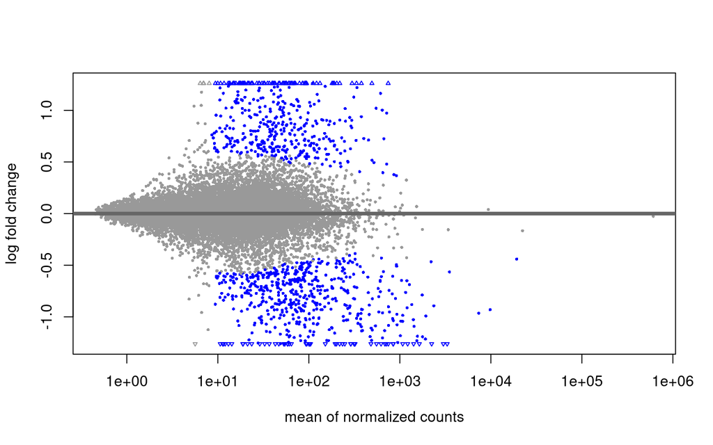

```r
plotMA(shrunk_urea_compare)
```

```r
result_urea_compare <- shrunk_urea_compare[order(shrunk_urea_compare$padj), ]

table(shrunk_urea_compare$padj<0.05)
```

```
##
## FALSE  TRUE
## 10727   762
```

```r
result_urea_compare <- merge(as.data.frame(result_urea_compare),
                 as.data.frame(counts(dds, normalized=TRUE)),
                 by="row.names",
                 sort=FALSE)

names(result_urea_compare)[1] <- "Gene_id"
str(result_urea_compare)
```

```
## 'data.frame':    18767 obs. of  14 variables:
##  $ Gene_id       : 'AsIs' chr  "AT4G10340" "AT5G64120" "AT4G30270" "AT2G34430" ...
##  $ baseMean      : num  1637.4 298.5 744.2 1218.3 93.2 ...
##  $ log2FoldChange: num  -1.49 2.41 2.36 -1.55 2.68 ...
##  $ lfcSE         : num  0.158 0.276 0.279 0.182 0.34 ...
##  $ pvalue        : num  2.38e-23 1.19e-22 1.29e-21 5.06e-20 4.61e-19 ...
##  $ padj          : num  2.74e-19 6.85e-19 4.96e-18 1.45e-16 1.06e-15 ...
##  $ SRR8311214    : num  2280.8 105.9 469.1 1774.9 10.8 ...
##  $ SRR8311215    : num  2109.93 94.3 465.6 1473.42 5.89 ...
##  $ SRR8311216    : num  1970.8 114.4 233.4 1657.3 19.1 ...
##  $ SRR8311218    : num  2219 125.8 237.9 1750.9 27.2 ...
##  $ SRR8311219    : num  2261 83 268.3 1532.2 34.6 ...
##  $ SRR8311226    : num  710 813 1539 568 267 ...
##  $ SRR8311227    : num  769 576 1603 438 216 ...
##  $ SRR8311228    : num  779 475 1138 552 164 ...
```

```r
head(result_urea_compare)
```

```
##     Gene_id   baseMean log2FoldChange     lfcSE       pvalue         padj
## 1 AT4G10340 1637.44498      -1.494123 0.1583094 2.383608e-23 2.738527e-19
## 2 AT5G64120  298.46213       2.409674 0.2760458 1.192882e-22 6.852508e-19
## 3 AT4G30270  744.18880       2.356695 0.2789628 1.294432e-21 4.957242e-18
## 4 AT2G34430 1218.30165      -1.552136 0.1815641 5.058129e-20 1.452821e-16
## 5 AT4G15610   93.20197       2.684037 0.3397821 4.608409e-19 1.058920e-15
## 6 AT3G54890  747.15947      -1.411976 0.1687273 6.221532e-19 1.191320e-15
##   SRR8311214  SRR8311215 SRR8311216 SRR8311218 SRR8311219 SRR8311226 SRR8311227
## 1 2280.78084 2109.931062 1970.82013 2219.04765 2261.01927   709.9491   769.4071
## 2  105.93200   94.298595  114.38382  125.83018   82.97318   812.6091   576.4408
## 3  469.12743  465.599313  233.36929  237.89170  268.27996  1538.8589  1602.7266
## 4 1774.90149 1473.415546 1657.25068 1750.91351 1532.23814   567.7512   437.5542
## 5   10.80939    5.893662   19.06397   27.15484   34.57216   267.4014   216.3189
## 6  964.19740  978.347923  844.73111 1043.35781 1045.46212   389.1367   336.7692
##   SRR8311228
## 1   778.6047
## 2   475.2295
## 3  1137.6572
## 4   552.3885
## 5   164.4013
## 6   375.2734
```

```r
result_urea_compare$diffexpressed <- "Unchanged"

result_urea_compare$diffexpressed[result_urea_compare$padj < 0.05 & result_urea_compare$log2FoldChange > 1] <- "Upregulated"

result_urea_compare$diffexpressed[result_urea_compare$padj < 0.05 & result_urea_compare$log2FoldChange < -1] <- "Downregulated"

str(result_urea_compare)
```

```
## 'data.frame':    18767 obs. of  15 variables:
##  $ Gene_id       : 'AsIs' chr  "AT4G10340" "AT5G64120" "AT4G30270" "AT2G34430" ...
##  $ baseMean      : num  1637.4 298.5 744.2 1218.3 93.2 ...
##  $ log2FoldChange: num  -1.49 2.41 2.36 -1.55 2.68 ...
##  $ lfcSE         : num  0.158 0.276 0.279 0.182 0.34 ...
##  $ pvalue        : num  2.38e-23 1.19e-22 1.29e-21 5.06e-20 4.61e-19 ...
##  $ padj          : num  2.74e-19 6.85e-19 4.96e-18 1.45e-16 1.06e-15 ...
##  $ SRR8311214    : num  2280.8 105.9 469.1 1774.9 10.8 ...
##  $ SRR8311215    : num  2109.93 94.3 465.6 1473.42 5.89 ...
##  $ SRR8311216    : num  1970.8 114.4 233.4 1657.3 19.1 ...
##  $ SRR8311218    : num  2219 125.8 237.9 1750.9 27.2 ...
##  $ SRR8311219    : num  2261 83 268.3 1532.2 34.6 ...
##  $ SRR8311226    : num  710 813 1539 568 267 ...
##  $ SRR8311227    : num  769 576 1603 438 216 ...
##  $ SRR8311228    : num  779 475 1138 552 164 ...
##  $ diffexpressed : chr  "Downregulated" "Upregulated" "Upregulated" "Downregulated" ...
```

```r
head(result_urea_compare)
```

```
##     Gene_id   baseMean log2FoldChange     lfcSE       pvalue         padj
## 1 AT4G10340 1637.44498      -1.494123 0.1583094 2.383608e-23 2.738527e-19
## 2 AT5G64120  298.46213       2.409674 0.2760458 1.192882e-22 6.852508e-19
## 3 AT4G30270  744.18880       2.356695 0.2789628 1.294432e-21 4.957242e-18
## 4 AT2G34430 1218.30165      -1.552136 0.1815641 5.058129e-20 1.452821e-16
## 5 AT4G15610   93.20197       2.684037 0.3397821 4.608409e-19 1.058920e-15
## 6 AT3G54890  747.15947      -1.411976 0.1687273 6.221532e-19 1.191320e-15
##   SRR8311214  SRR8311215 SRR8311216 SRR8311218 SRR8311219 SRR8311226 SRR8311227
## 1 2280.78084 2109.931062 1970.82013 2219.04765 2261.01927   709.9491   769.4071
## 2  105.93200   94.298595  114.38382  125.83018   82.97318   812.6091   576.4408
## 3  469.12743  465.599313  233.36929  237.89170  268.27996  1538.8589  1602.7266
## 4 1774.90149 1473.415546 1657.25068 1750.91351 1532.23814   567.7512   437.5542
## 5   10.80939    5.893662   19.06397   27.15484   34.57216   267.4014   216.3189
## 6  964.19740  978.347923  844.73111 1043.35781 1045.46212   389.1367   336.7692
##   SRR8311228 diffexpressed
## 1   778.6047 Downregulated
## 2   475.2295   Upregulated
## 3  1137.6572   Upregulated
## 4   552.3885 Downregulated
## 5   164.4013   Upregulated
## 6   375.2734 Downregulated
```

```r
#write.csv(result_urea_compare,
 #         "urea6h_vs_urea48h_full_matrix_042425.csv",
  #        row.names = FALSE)
```

## Urea 48h v 6h Volcano Plot

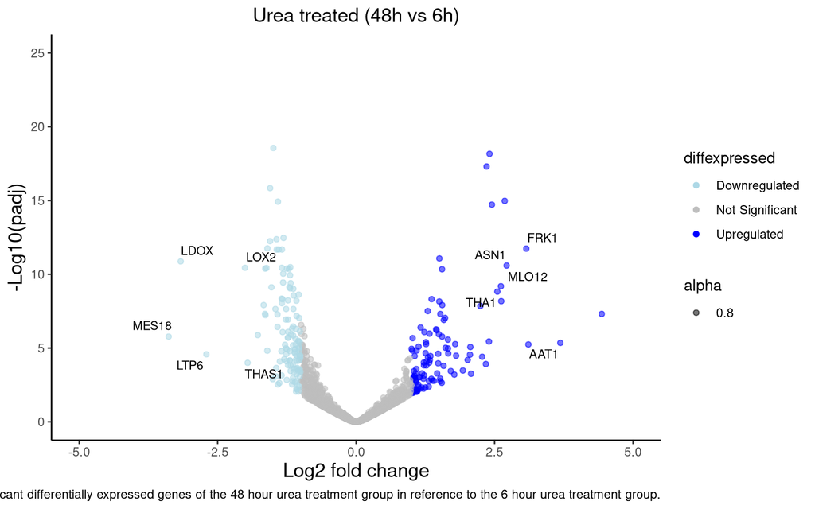

```r
result_urea_compare <- read.csv("urea6h_vs_urea48h_full_matrix_042525.csv")


genes_to_label <- c("AAT1", "FRK1", "ASN1", "MLO12", "MES18", "LDOX", "LTP6", "LOX2", "THAS1", "THA1")

result_urea_compare$label <- ifelse(result_urea_compare$symbol %in% genes_to_label,
                                   result_urea_compare$symbol,
                                   NA)


u48h_v_u6h_Volcano <- ggplot(result_urea_compare) +
  geom_point(aes(x = log2FoldChange, y = -log10(padj), color = diffexpressed, alpha = 0.8)) +
  geom_text_repel(aes(x = log2FoldChange,
                      y = -log10(padj),
                      label = label),
                  size = 3,
                  max.overlaps = Inf) +
  theme_classic() +
  ggtitle("Urea treated (48h vs 6h)") +
  labs(caption = "Significant differentially expressed genes of the 48 hour urea treatment group in reference to the 6 hour urea treatment group.") +
  xlab("Log2 fold change") +
  ylab("-Log10(padj)") +
  theme(legend.position = "right",
        plot.title = element_text(size = rel(1.25), hjust = 0.5),
        axis.title = element_text(size = rel(1.25))) +
  scale_color_manual(values = c("lightblue", "grey", "blue"),
                     labels = c("Downregulated", "Not Significant", "Upregulated")) +
  scale_x_continuous(limits = c(-5, 5)) +
  coord_cartesian(ylim = c(0, 25), clip = "off")

u48h_v_u6h_Volcano
```

```r
#ggsave(filename = "48hV6h_Volcano.pdf", plot = u48h_v_u6h_Volcano, width = 6, height = 4)
```

## Urea 6h v Mock lfcShrink

```r
shrunk_urea6hVmock_compare <- lfcShrink(dds,
                                contrast = c("group", "urea_6h", "mock_0h"),
                                type = "ashr")  # or "apeglm" if available
```

```
## using 'ashr' for LFC shrinkage. If used in published research, please cite:
##     Stephens, M. (2016) False discovery rates: a new deal. Biostatistics, 18:2.
##     https://doi.org/10.1093/biostatistics/kxw041
```

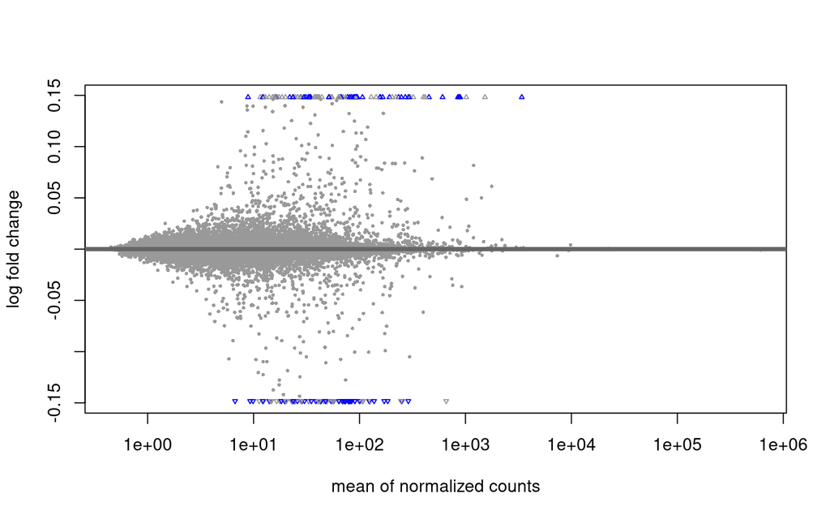

```r
plotMA(shrunk_urea6hVmock_compare)
```

```r
result_urea6hVmock_compare <- shrunk_urea6hVmock_compare[order(shrunk_urea6hVmock_compare$padj), ]

table(shrunk_urea6hVmock_compare$padj<0.05)
```

```
##
## FALSE  TRUE
## 14344    56
```

```r
result_urea6hVmock_compare <- merge(as.data.frame(result_urea6hVmock_compare),
                 as.data.frame(counts(dds, normalized=TRUE)),
                 by="row.names",
                 sort=FALSE)

names(result_urea6hVmock_compare)[1] <- "Gene_id"
str(result_urea6hVmock_compare)
```

```
## 'data.frame':    18767 obs. of  14 variables:
##  $ Gene_id       : 'AsIs' chr  "AT3G01420" "AT4G32940" "AT3G10040" "AT5G65010" ...
##  $ baseMean      : num  155.7 451.7 30.2 71.5 870.4 ...
##  $ log2FoldChange: num  2.27 1.48 -2.83 -1.84 1.17 ...
##  $ lfcSE         : num  0.351 0.218 0.473 0.309 0.195 ...
##  $ pvalue        : num  2.53e-12 2.51e-12 4.61e-12 2.33e-10 7.54e-10 ...
##  $ padj          : num  1.82e-08 1.82e-08 2.21e-08 8.40e-07 2.17e-06 ...
##  $ SRR8311214    : num  21.6 160 67 192.4 462.6 ...
##  $ SRR8311215    : num  17.7 117.9 106.1 129.7 477.4 ...
##  $ SRR8311216    : num  26.3 152.5 51.9 121 499 ...
##  $ SRR8311218    : num  95.23 455.13 4.97 31.36 1241.47 ...
##  $ SRR8311219    : num  206.05 420.4 5.53 41.49 997.06 ...
##  $ SRR8311226    : num  361.738 908.333 0.694 16.994 1297.469 ...
##  $ SRR8311227    : num  240.9 749.74 1.23 14.75 1016.45 ...
##  $ SRR8311228    : num  275.76 649.28 3.95 24.11 971.5 ...
```

```r
head(result_urea6hVmock_compare)
```

```
##     Gene_id  baseMean log2FoldChange     lfcSE       pvalue         padj
## 1 AT3G01420 155.65903       2.274726 0.3512658 2.528340e-12 1.820405e-08
## 2 AT4G32940 451.65522       1.479497 0.2180476 2.509496e-12 1.820405e-08
## 3 AT3G10040  30.17612      -2.830457 0.4730992 4.609729e-12 2.212670e-08
## 4 AT5G65010  71.46617      -1.839989 0.3089873 2.332454e-10 8.396836e-07
## 5 AT1G47128 870.36722       1.167158 0.1945547 7.543727e-10 2.172594e-06
## 6 AT2G38170  82.39496      -1.598946 0.2905717 5.775610e-09 1.386146e-05
##   SRR8311214 SRR8311215 SRR8311216  SRR8311218 SRR8311219   SRR8311226
## 1   21.61878   17.68099   26.29513   95.233172 206.050074  361.7376182
## 2  159.97894  117.87324  152.51176  455.130422 420.397467  908.3325235
## 3   67.01820  106.08592   51.93289    4.972013   5.531546    0.6936484
## 4  192.40710  129.66057  120.95761   31.361928  41.486592   16.9943847
## 5  462.64180  477.38664  498.95013 1241.473403 997.061098 1297.4692518
## 6  198.89274  159.12888  119.64285   43.983192  48.401024   24.9713409
##    SRR8311227 SRR8311228
## 1  240.900625 275.755837
## 2  749.741742 649.275666
## 3    1.229085   3.945632
## 4   14.749018  24.112196
## 5 1016.453149 971.502280
## 6   35.643460  28.496231
```

```r
result_urea6hVmock_compare$diffexpressed <- "Unchanged"

result_urea6hVmock_compare$diffexpressed[result_urea6hVmock_compare$padj < 0.05 & result_urea6hVmock_compare$log2FoldChange > 1] <- "Upregulated"

result_urea6hVmock_compare$diffexpressed[result_urea6hVmock_compare$padj < 0.05 & result_urea6hVmock_compare$log2FoldChange < -1] <- "Downregulated"

str(result_urea6hVmock_compare)
```

```
## 'data.frame':    18767 obs. of  15 variables:
##  $ Gene_id       : 'AsIs' chr  "AT3G01420" "AT4G32940" "AT3G10040" "AT5G65010" ...
##  $ baseMean      : num  155.7 451.7 30.2 71.5 870.4 ...
##  $ log2FoldChange: num  2.27 1.48 -2.83 -1.84 1.17 ...
##  $ lfcSE         : num  0.351 0.218 0.473 0.309 0.195 ...
##  $ pvalue        : num  2.53e-12 2.51e-12 4.61e-12 2.33e-10 7.54e-10 ...
##  $ padj          : num  1.82e-08 1.82e-08 2.21e-08 8.40e-07 2.17e-06 ...
##  $ SRR8311214    : num  21.6 160 67 192.4 462.6 ...
##  $ SRR8311215    : num  17.7 117.9 106.1 129.7 477.4 ...
##  $ SRR8311216    : num  26.3 152.5 51.9 121 499 ...
##  $ SRR8311218    : num  95.23 455.13 4.97 31.36 1241.47 ...
##  $ SRR8311219    : num  206.05 420.4 5.53 41.49 997.06 ...
##  $ SRR8311226    : num  361.738 908.333 0.694 16.994 1297.469 ...
##  $ SRR8311227    : num  240.9 749.74 1.23 14.75 1016.45 ...
##  $ SRR8311228    : num  275.76 649.28 3.95 24.11 971.5 ...
##  $ diffexpressed : chr  "Upregulated" "Upregulated" "Downregulated" "Downregulated" ...
```

```r
head(result_urea6hVmock_compare)
```

```
##     Gene_id  baseMean log2FoldChange     lfcSE       pvalue         padj
## 1 AT3G01420 155.65903       2.274726 0.3512658 2.528340e-12 1.820405e-08
## 2 AT4G32940 451.65522       1.479497 0.2180476 2.509496e-12 1.820405e-08
## 3 AT3G10040  30.17612      -2.830457 0.4730992 4.609729e-12 2.212670e-08
## 4 AT5G65010  71.46617      -1.839989 0.3089873 2.332454e-10 8.396836e-07
## 5 AT1G47128 870.36722       1.167158 0.1945547 7.543727e-10 2.172594e-06
## 6 AT2G38170  82.39496      -1.598946 0.2905717 5.775610e-09 1.386146e-05
##   SRR8311214 SRR8311215 SRR8311216  SRR8311218 SRR8311219   SRR8311226
## 1   21.61878   17.68099   26.29513   95.233172 206.050074  361.7376182
## 2  159.97894  117.87324  152.51176  455.130422 420.397467  908.3325235
## 3   67.01820  106.08592   51.93289    4.972013   5.531546    0.6936484
## 4  192.40710  129.66057  120.95761   31.361928  41.486592   16.9943847
## 5  462.64180  477.38664  498.95013 1241.473403 997.061098 1297.4692518
## 6  198.89274  159.12888  119.64285   43.983192  48.401024   24.9713409
##    SRR8311227 SRR8311228 diffexpressed
## 1  240.900625 275.755837   Upregulated
## 2  749.741742 649.275666   Upregulated
## 3    1.229085   3.945632 Downregulated
## 4   14.749018  24.112196 Downregulated
## 5 1016.453149 971.502280   Upregulated
## 6   35.643460  28.496231 Downregulated
```

```r
#write.csv(result_urea6hVmock_compare,
 #         "urea6h_vs_mock0h_full_matrix_042425.csv",
  #        row.names = FALSE)
```

## Urea 6h v Mock Volcano Plot

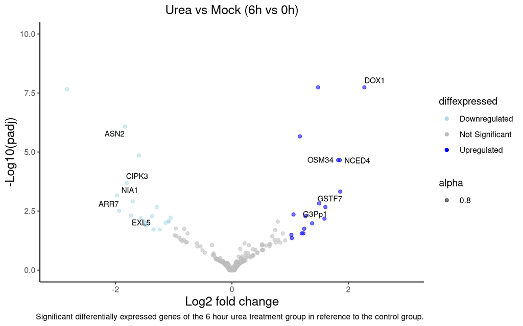

```r
result_urea6hVmock_compare <- read.csv("urea6h_vs_mock0h_full_matrix_042525.csv")


genes_to_label <- c("NIA1", "ARR7", "ASN2", "CIPK3", "EXL5", "DOX1", "GSTF7", "NCED4", "OSM34", "G3Pp1")

result_urea6hVmock_compare$label <- ifelse(result_urea6hVmock_compare$symbol %in% genes_to_label,
                                   result_urea6hVmock_compare$symbol,
                                   NA)


u6h_v_mock_Volcano <- ggplot(result_urea6hVmock_compare) +
  geom_point(aes(x = log2FoldChange, y = -log10(padj), color = diffexpressed, alpha = 0.8)) +
  geom_text_repel(aes(x = log2FoldChange,
                      y = -log10(padj),
                      label = label),
                  size = 3,
                  max.overlaps = Inf) +
  theme_classic() +
  ggtitle("Urea vs Mock (6h vs 0h)") +
  labs(caption = "Significant differentially expressed genes of the 6 hour urea treatment group in reference to the control group.") +
  xlab("Log2 fold change") +
  ylab("-Log10(padj)") +
  theme(legend.position = "right",
        plot.title = element_text(size = rel(1.25), hjust = 0.5),
        axis.title = element_text(size = rel(1.25))) +
  scale_color_manual(values = c("lightblue", "grey", "blue"),
                     labels = c("Downregulated", "Not Significant", "Upregulated")) +
  scale_x_continuous(limits = c(-3, 3)) +
  coord_cartesian(ylim = c(0, 10), clip = "off")

u6h_v_mock_Volcano
```

```r
#ggsave(filename = "6hVmock_Volcano.pdf", plot = u6h_v_mock_Volcano, width = 6, height = 4)
```

## Urea 48h v Mock lfcShrink

```r
shrunk_urea48hVmock_compare <- lfcShrink(dds,
                                contrast = c("group", "urea_48h", "mock_0h"),
                                type = "ashr")  # or "apeglm" if available
```

```
## using 'ashr' for LFC shrinkage. If used in published research, please cite:
##     Stephens, M. (2016) False discovery rates: a new deal. Biostatistics, 18:2.
##     https://doi.org/10.1093/biostatistics/kxw041
```

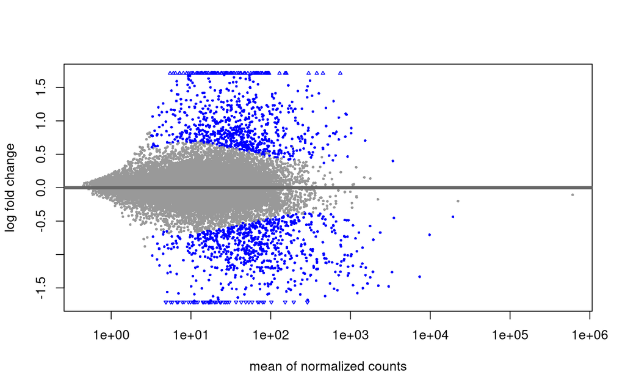

```r
plotMA(shrunk_urea48hVmock_compare)
```

```r
result_urea48hVmock_compare <- shrunk_urea48hVmock_compare[order(shrunk_urea48hVmock_compare$padj), ]

table(shrunk_urea48hVmock_compare$padj<0.05)
```

```
##
## FALSE  TRUE
## 14282  1209
```

```r
result_urea48hVmock_compare <- merge(as.data.frame(result_urea48hVmock_compare),
                 as.data.frame(counts(dds, normalized=TRUE)),
                 by="row.names",
                 sort=FALSE)

names(result_urea48hVmock_compare)[1] <- "Gene_id"
str(result_urea48hVmock_compare)
```

```
## 'data.frame':    18767 obs. of  14 variables:
##  $ Gene_id       : 'AsIs' chr  "AT4G32940" "AT3G45140" "AT3G62030" "AT3G01420" ...
##  $ baseMean      : num  452 194 288 156 1637 ...
##  $ log2FoldChange: num  2.32 -2.83 -1.86 3.49 -1.43 ...
##  $ lfcSE         : num  0.209 0.277 0.191 0.342 0.144 ...
##  $ pvalue        : num  8.32e-32 5.62e-26 5.76e-26 1.46e-25 2.98e-25 ...
##  $ padj          : num  1.29e-27 2.97e-22 2.97e-22 5.65e-22 9.24e-22 ...
##  $ SRR8311214    : num  160 387 454 21.6 2280.8 ...
##  $ SRR8311215    : num  117.9 282.9 377.2 17.7 2109.9 ...
##  $ SRR8311216    : num  152.5 322.1 454.9 26.3 1970.8 ...
##  $ SRR8311218    : num  455.1 162.5 323.6 95.2 2219 ...
##  $ SRR8311219    : num  420 264 347 206 2261 ...
##  $ SRR8311226    : num  908.3 26.7 106.8 361.7 709.9 ...
##  $ SRR8311227    : num  749.7 54.1 130.3 240.9 769.4 ...
##  $ SRR8311228    : num  649.3 55.7 108.3 275.8 778.6 ...
```

```r
head(result_urea48hVmock_compare)
```

```
##     Gene_id   baseMean log2FoldChange     lfcSE       pvalue         padj
## 1 AT4G32940  451.65522       2.322686 0.2088205 8.316152e-32 1.288255e-27
## 2 AT3G45140  194.39095      -2.825656 0.2765005 5.622896e-26 2.972132e-22
## 3 AT3G62030  287.76910      -1.856688 0.1913241 5.755856e-26 2.972132e-22
## 4 AT3G01420  155.65903       3.490467 0.3422353 1.458632e-25 5.648917e-22
## 5 AT4G10340 1637.44498      -1.433637 0.1437147 2.980975e-25 9.235655e-22
## 6 AT4G15610   93.20197       3.660470 0.3652102 7.574763e-25 1.955677e-21
##   SRR8311214  SRR8311215 SRR8311216 SRR8311218 SRR8311219 SRR8311226 SRR8311227
## 1  159.97894  117.873244  152.51176  455.13042  420.39747  908.33252  749.74174
## 2  386.97609  282.895785  322.11536  162.54658  264.13130   26.70546   54.07973
## 3  453.99429  377.194380  454.90578  323.56331  347.10449  106.82185  130.28299
## 4   21.61878   17.680987   26.29513   95.23317  206.05007  361.73762  240.90063
## 5 2280.78084 2109.931062 1970.82013 2219.04765 2261.01927  709.94909  769.40710
## 6   10.80939    5.893662   19.06397   27.15484   34.57216  267.40144  216.31893
##   SRR8311228
## 1  649.27567
## 2   55.67725
## 3  108.28568
## 4  275.75584
## 5  778.60472
## 6  164.40133
```

```r
result_urea48hVmock_compare$diffexpressed <- "Unchanged"

result_urea48hVmock_compare$diffexpressed[result_urea48hVmock_compare$padj < 0.05 & result_urea48hVmock_compare$log2FoldChange > 1] <- "Upregulated"

result_urea48hVmock_compare$diffexpressed[result_urea48hVmock_compare$padj < 0.05 & result_urea48hVmock_compare$log2FoldChange < -1] <- "Downregulated"

str(result_urea48hVmock_compare)
```

```
## 'data.frame':    18767 obs. of  15 variables:
##  $ Gene_id       : 'AsIs' chr  "AT4G32940" "AT3G45140" "AT3G62030" "AT3G01420" ...
##  $ baseMean      : num  452 194 288 156 1637 ...
##  $ log2FoldChange: num  2.32 -2.83 -1.86 3.49 -1.43 ...
##  $ lfcSE         : num  0.209 0.277 0.191 0.342 0.144 ...
##  $ pvalue        : num  8.32e-32 5.62e-26 5.76e-26 1.46e-25 2.98e-25 ...
##  $ padj          : num  1.29e-27 2.97e-22 2.97e-22 5.65e-22 9.24e-22 ...
##  $ SRR8311214    : num  160 387 454 21.6 2280.8 ...
##  $ SRR8311215    : num  117.9 282.9 377.2 17.7 2109.9 ...
##  $ SRR8311216    : num  152.5 322.1 454.9 26.3 1970.8 ...
##  $ SRR8311218    : num  455.1 162.5 323.6 95.2 2219 ...
##  $ SRR8311219    : num  420 264 347 206 2261 ...
##  $ SRR8311226    : num  908.3 26.7 106.8 361.7 709.9 ...
##  $ SRR8311227    : num  749.7 54.1 130.3 240.9 769.4 ...
##  $ SRR8311228    : num  649.3 55.7 108.3 275.8 778.6 ...
##  $ diffexpressed : chr  "Upregulated" "Downregulated" "Downregulated" "Upregulated" ...
```

```r
head(result_urea48hVmock_compare)
```

```
##     Gene_id   baseMean log2FoldChange     lfcSE       pvalue         padj
## 1 AT4G32940  451.65522       2.322686 0.2088205 8.316152e-32 1.288255e-27
## 2 AT3G45140  194.39095      -2.825656 0.2765005 5.622896e-26 2.972132e-22
## 3 AT3G62030  287.76910      -1.856688 0.1913241 5.755856e-26 2.972132e-22
## 4 AT3G01420  155.65903       3.490467 0.3422353 1.458632e-25 5.648917e-22
## 5 AT4G10340 1637.44498      -1.433637 0.1437147 2.980975e-25 9.235655e-22
## 6 AT4G15610   93.20197       3.660470 0.3652102 7.574763e-25 1.955677e-21
##   SRR8311214  SRR8311215 SRR8311216 SRR8311218 SRR8311219 SRR8311226 SRR8311227
## 1  159.97894  117.873244  152.51176  455.13042  420.39747  908.33252  749.74174
## 2  386.97609  282.895785  322.11536  162.54658  264.13130   26.70546   54.07973
## 3  453.99429  377.194380  454.90578  323.56331  347.10449  106.82185  130.28299
## 4   21.61878   17.680987   26.29513   95.23317  206.05007  361.73762  240.90063
## 5 2280.78084 2109.931062 1970.82013 2219.04765 2261.01927  709.94909  769.40710
## 6   10.80939    5.893662   19.06397   27.15484   34.57216  267.40144  216.31893
##   SRR8311228 diffexpressed
## 1  649.27567   Upregulated
## 2   55.67725 Downregulated
## 3  108.28568 Downregulated
## 4  275.75584   Upregulated
## 5  778.60472 Downregulated
## 6  164.40133   Upregulated
```

```r
#write.csv(result_urea48hVmock_compare,
          #"urea48h_vs_mock0h_full_matrix_042425.csv",
          #row.names = FALSE)
```

## Urea 48h v Mock Volcano Plot

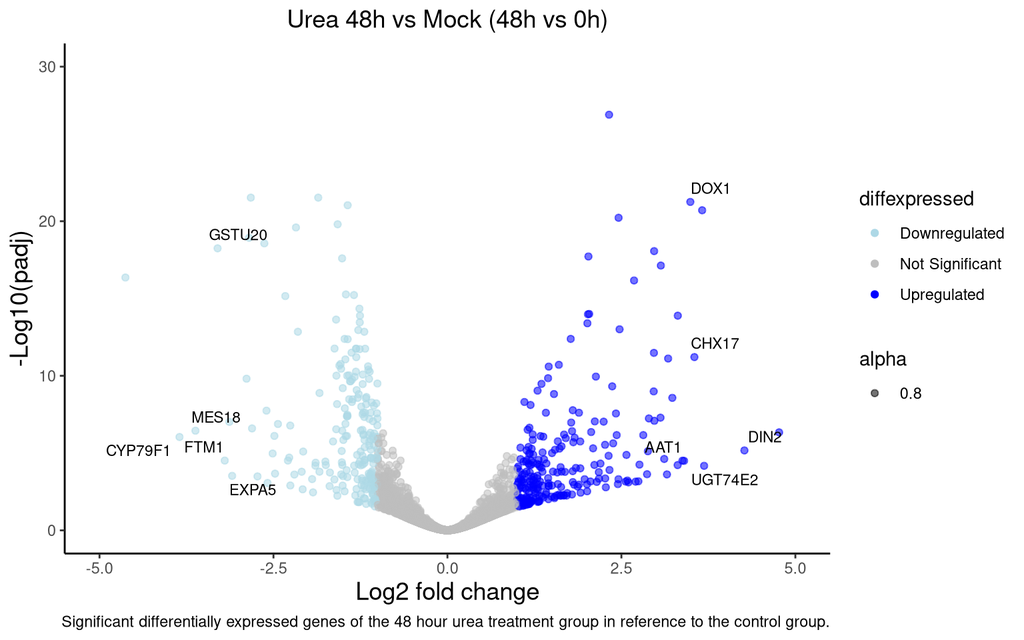

```r
result_urea48hVmock_compare <- read.csv("urea48h_vs_mock0h_full_matrix_042525.csv")


genes_to_label <- c("CYP79F1", "MES18", "GSTU20", "FTM1", "EXPA5", "DIN2", "UGT74E2", "CHX17", "DOX1", "AAT1")

result_urea48hVmock_compare$label <- ifelse(result_urea48hVmock_compare$symbol %in% genes_to_label,
                                   result_urea48hVmock_compare$symbol,
                                   NA)


u48h_v_mock_Volcano <- ggplot(result_urea48hVmock_compare) +
  geom_point(aes(x = log2FoldChange, y = -log10(padj), color = diffexpressed, alpha = 0.8)) +
  geom_text_repel(aes(x = log2FoldChange,
                      y = -log10(padj),
                      label = label),
                  size = 3,
                  max.overlaps = Inf) +
  theme_classic() +
  ggtitle("Urea 48h vs Mock (48h vs 0h)") +
  labs(caption = "Significant differentially expressed genes of the 48 hour urea treatment group in reference to the control group.") +
  xlab("Log2 fold change") +
  ylab("-Log10(padj)") +
  theme(legend.position = "right",
        plot.title = element_text(size = rel(1.25), hjust = 0.5),
        axis.title = element_text(size = rel(1.25))) +
  scale_color_manual(values = c("lightblue", "grey", "blue"),
                     labels = c("Downregulated", "Not Significant", "Upregulated")) +
  scale_x_continuous(limits = c(-5, 5)) +
  coord_cartesian(ylim = c(0, 30), clip = "off")

u48h_v_mock_Volcano
```

```r
#ggsave(filename = "48hVmock_Volcano.pdf", plot = u48h_v_mock_Volcano, width = 6, height = 4)
```

# Supplementary Barplot of the Amount of Significant DE per Treatment Group

This was conducted to visualize the size of the data being worked on.

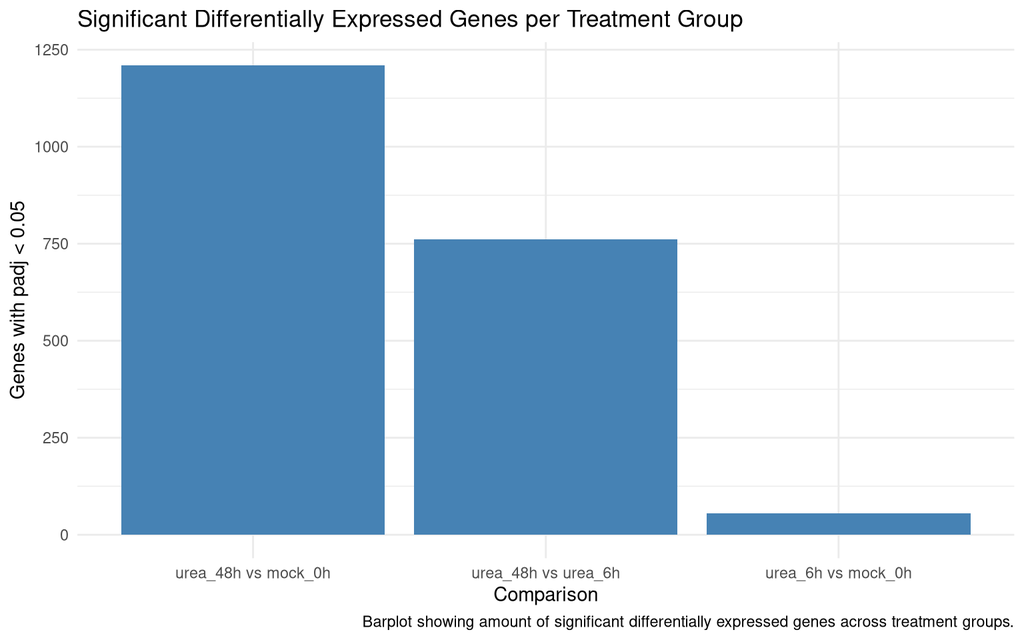

```r
sig_6h <- sum(res_urea6h_mock0h$padj < 0.05, na.rm = TRUE)
sig_48h <- sum(res_urea48h_mock0h$padj < 0.05, na.rm = TRUE)
sig_UvU <- sum(res_urea48h_urea6h$padj < 0.05, na.rm =TRUE)

de_summary <- data.frame(
  comparison = c("urea_6h vs mock_0h", "urea_48h vs mock_0h", "urea_48h vs urea_6h"),
  sig_genes = c(sig_6h, sig_48h, sig_UvU)
)

SigDE_barplot <- ggplot(de_summary, aes(x = comparison, y = sig_genes)) +
  geom_col(fill = "steelblue") +
  labs(caption = "Barplot showing amount of significant differentially expressed genes across treatment groups.", x = "Comparison", y = "Genes with padj < 0.05",
       title = "Significant Differentially Expressed Genes per Treatment Group") +
  theme_minimal()

SigDE_barplot
```

```r
#ggsave(filename = "SigDE_barplot.pdf", plot = SigDE_barplot, width = 6, height = 4)
```

# Boxplots for Specific Genes

These genes were selected from the data used in the volcano plots to visualize thier counts per different treatment groups. Since it is a time series study, this helps visualize the counts over time. That is why the reordering of the group levels is important in this code so it makes logical sense when examining each boxplot.

## Boxplot of Normalized Counts for AAT1

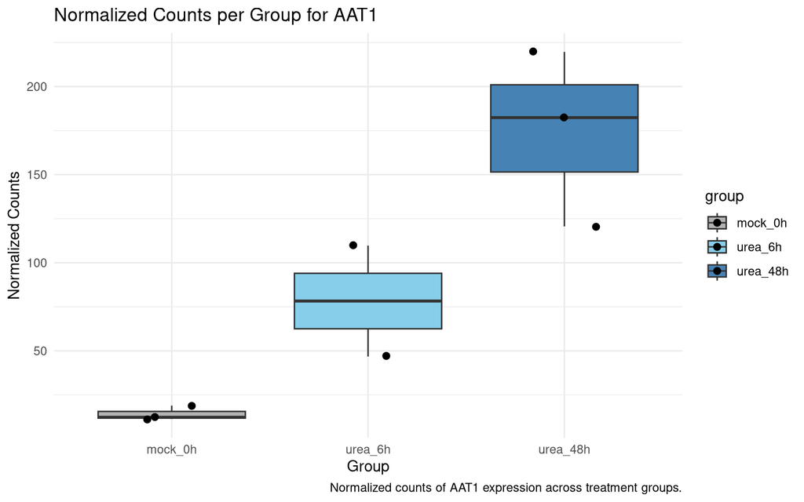

```r
norm_counts_AAT1 <- plotCounts(dds,
                               gene = "AT1G02920",
                               intgroup = "group",
                               returnData = TRUE)

norm_counts_AAT1$group <- factor(norm_counts_AAT1$group,
                                 levels = c("mock_0h", "urea_6h", "urea_48h"))

AAT1_plot <- ggplot(norm_counts_AAT1, aes(x = group, y = count, fill = group)) +
  geom_boxplot(outlier.shape = NA) +
  geom_jitter(width = 0.2, size = 2) +
  scale_fill_manual(values = c(
    "mock_0h" = "gray70",
    "urea_6h" = "skyblue",
    "urea_48h" = "steelblue"
  )) +
  labs(caption = "Normalized counts of AAT1 expression across treatment groups.",
    title = "Normalized Counts per Group for AAT1",
    x = "Group",
    y = "Normalized Counts"
  ) +
  theme_minimal()

AAT1_plot
```

```r
#ggsave(filename = "AAT1_normalized_counts.pdf", plot = AAT1_plot, width = 6, height = 4)
```

## Boxplot of Normalized Counts for DOX1

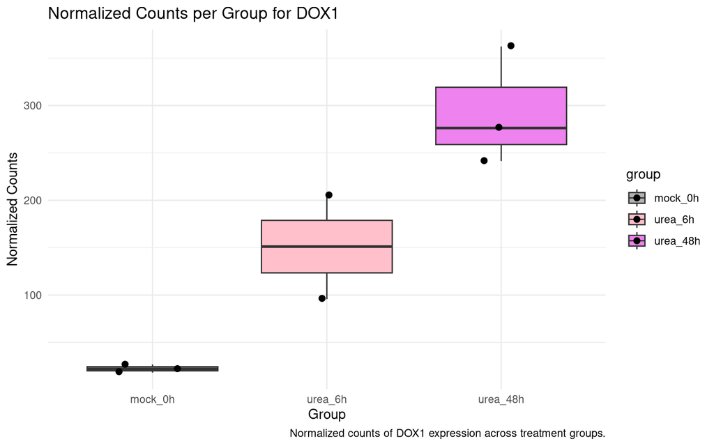

```r
norm_counts_DOX1 <- plotCounts(dds,
                               gene = "AT3G01420",
                               intgroup = "group",
                               returnData = TRUE)

norm_counts_DOX1$group <- factor(norm_counts_DOX1$group,
                                 levels = c("mock_0h", "urea_6h", "urea_48h"))

DOX1_plot <- ggplot(norm_counts_DOX1, aes(x = group, y = count, fill = group)) +
  geom_boxplot(outlier.shape = NA) +
  geom_jitter(width = 0.2, size = 2) +
  scale_fill_manual(values = c(
    "mock_0h" = "gray70",
    "urea_6h" = "pink",
    "urea_48h" = "violet"
  )) +
  labs(caption = "Normalized counts of DOX1 expression across treatment groups.",
    title = "Normalized Counts per Group for DOX1",
    x = "Group",
    y = "Normalized Counts"
  ) +
  theme_minimal()

DOX1_plot
```

```r
#ggsave(filename = "DOX1_normalized_counts.pdf", plot = DOX1_plot, width = 6, height = 4)
```